# EDA of Prosper Loan Data By Ramamohan Soma

### Description One

Median Net principal loss has increased in the year 2007 then decreased and was low in 2009 when prosper implemented strict guide lines. Then it increased again from 2011 to 2013. For all the credit scores Income Range of $100,000+ has higher median of Net principal Loss.

### Plot Two

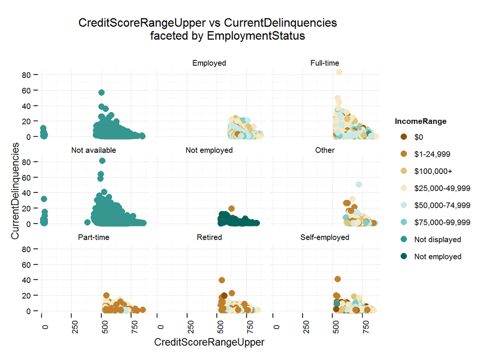

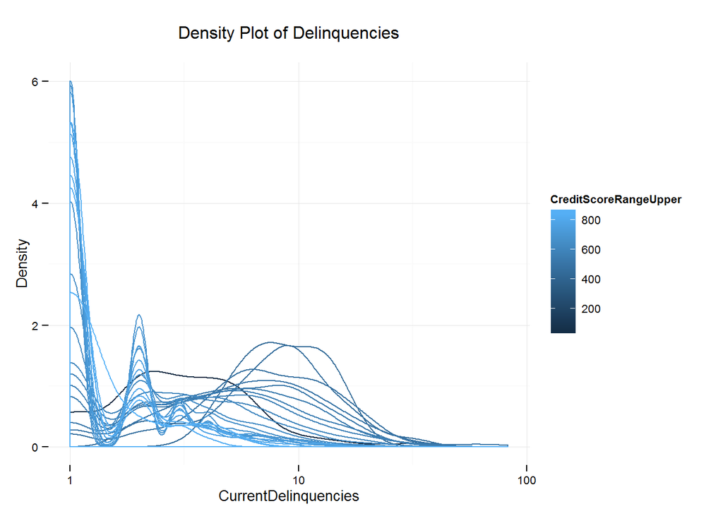

### Description Two

For all borrowers of various Income Ranges with Deliquencies, Credit Score range is between ~500-800. I can see there are many Deliquenicies for the Borrowers whose Employment Status is ‘Employed’ or ‘Full-time’ and Income Range varies. Also most of the Deliquencies > 50 belong to the Borrowers whose Employment Status is not specified or ‘Not displayed’ .‘Not Employed’ Borrowers have least Deliquencies. There are some Borrowers with Delinquencies whose credit score is way below 50. They belong to Employment Status not specified category. It would be interesting to know who they are.

### Plot Three

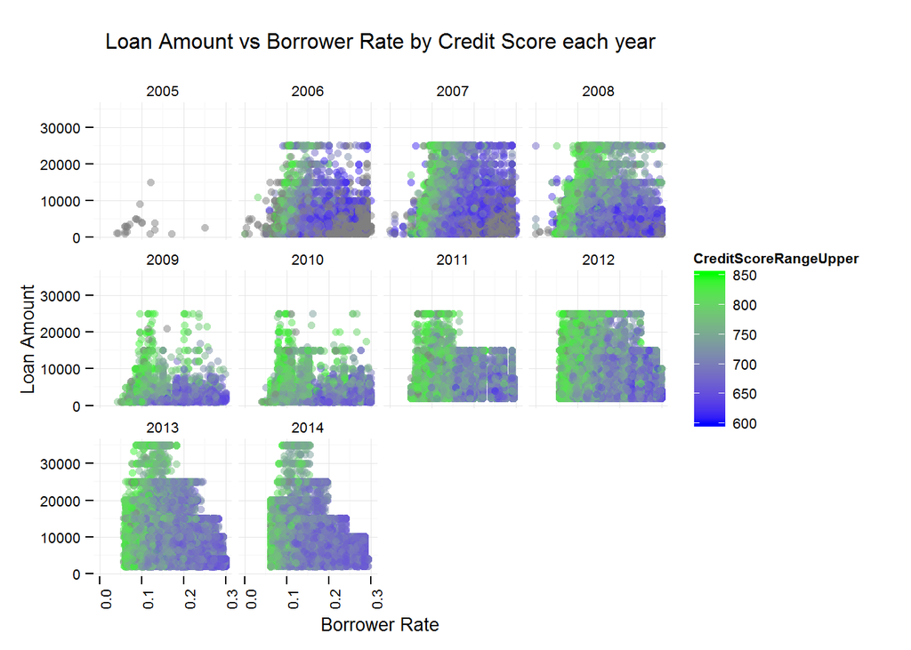

### Description Three

Borrowers with high Upper Range Creditscore are in the left of the plot and they generally have low interest rates. From 2010 to 2014 we can see Low Upper Range credit score borrowers have high interest rates. I think this is because of making the guide lines strict in 2009.

# Reflection

From my analysis it seems like Propser struggled in the intial years until 2008 with many deliquencies, no strict rules etc. As we can see there was no proper information like Income Range, Employment Status about the borrowers. In 2009 once Prosper was restructured and made the rules stricter, I can see the deliquencies dropped significantly.

I would like to explore more on how Interest and fees are varying among different Loans, how the loans are distributed accross different states. Also I want to learn more about the models and create more models on this data using the other features in the data for example model loans likely to be deliquent based on credit scores.

# References

- Common function in R: http://discussions.udacity.com/t/common-function-in-r/10404/2
- Reshape: http://www.statmethods.net/management/reshape.html
- Date Formats in R: http://www.r-bloggers.com/date-formats-in-r/
- Do more with dates and times in R with lubridate: http://cran.r-project.org/web/packages/lubridate/vignettes/lubridate.html
- Introduction of dplyr: dplyr Tutorial Part 1 : http://www.r-bloggers.com/hadley-wickhams-dplyr-tutorial-at-user-2014-part-1/
- Types of smoothers in ggplot2: http://www.ats.ucla.edu/stat/r/faq/smooths.htm
- An Introduction to reshape2 by Sean Anderson: http://seananderson.ca/2013/10/19/reshape.html
- Converting Between Long and Wide Format: http://www.cookbook-r.com/Manipulating_data/Converting_data_between_wide_and_long_format/
- Melt Data Frames: http://www.r-bloggers.com/melt/
- Cut Function: http://www.r-bloggers.com/r-function-of-the-day-cut-2/
- Bayesian Statistics and Marketing: http://www.perossi.org/home/bsm-1
- QuickR’s Graphical Parameters: http://www.statmethods.net/advgraphs/parameters.html
- facet_wrap: http://docs.ggplot2.org/0.9.3.1/facet_wrap.html
- Log Transformations: http://www.r-statistics.com/2013/05/log-transformations-for-skewed-and-wide-distributions-from-practical-data-science-with-r/
- Basic Structure of a Function: https://www.youtube.com/watch?v=Z1wB1rHAYzQ&list=PLOU2XLYxmsIK9qQfztXeybpHvru-TrqAP
- Defining a New Transformation in ggplot2 and the Scales Package: http://blog.ggplot2.org/post/25938265813/defining-a-new-transformation-for-ggplot2-scales
- ggplot2: axis manipulation and themes: http://rstudio-pubs-static.s3.amazonaws.com/3364_d1a578f521174152b46b19d0c83cbe7e.html
- An Introduction to corrplot package: http://cran.r-project.org/web/packages/corrplot/vignettes/corrplot-intro.html
- R Sub function: http://www.endmemo.com/program/R/sub.php
- ggplot2 - colors: http://docs.ggplot2.org/0.9.3.1/scale_gradient.html
- Beautiful plotting in R: A ggplot2 cheatsheet: http://zevross.com/blog/2014/08/04/beautiful-plotting-in-r-a-ggplot2-cheatsheet-3/
- Prosper: https://www.prosper.com/invest/marketplace-performance/
- Prosper: http://en.wikipedia.org/wiki/Prosper_Marketplace
- Prosper Ratings: https://www.prosper.com/invest/how-to-invest/prosper-ratings/
- Prosper: How it works: https://www.prosper.com/welcome/how-it-works/